# File S11: Metagenome analaysis

Eric S. Tvedte

June 6, 2019

## Input dataset

The input for the following analysis is a tab-delimited text file, containing the following data columns: sample ID, experiment, experimental group (CHANGE “TAG” IN .txt FILE to “GROUP”), barcode, primer category, technical replicates, number of paired reads, percentage of reads classified by kraken2, percentage of reads containing domain LCAs, and percentage of reads containing phylum LCAs greater than 0.5%. Each sample was given a sample number assignment so that patterns could be visualized matching the progression of the experiment and the comparison of Riptide to non-Riptide datasets.

Unix commands are given in blue

```r
library(ggplot2)
library(tidyverse)
in.path = "Y:/RDRIP/etvedte/meta_ETEC/RIPTIDEPAPER_meta_final.txt"
data <- read.table(in.path, header = T, sep = '\t')
```

# Raw read counts

### ETEC metagenome

Here, read pair counts are doubled and plotted for each metagenomic sample.

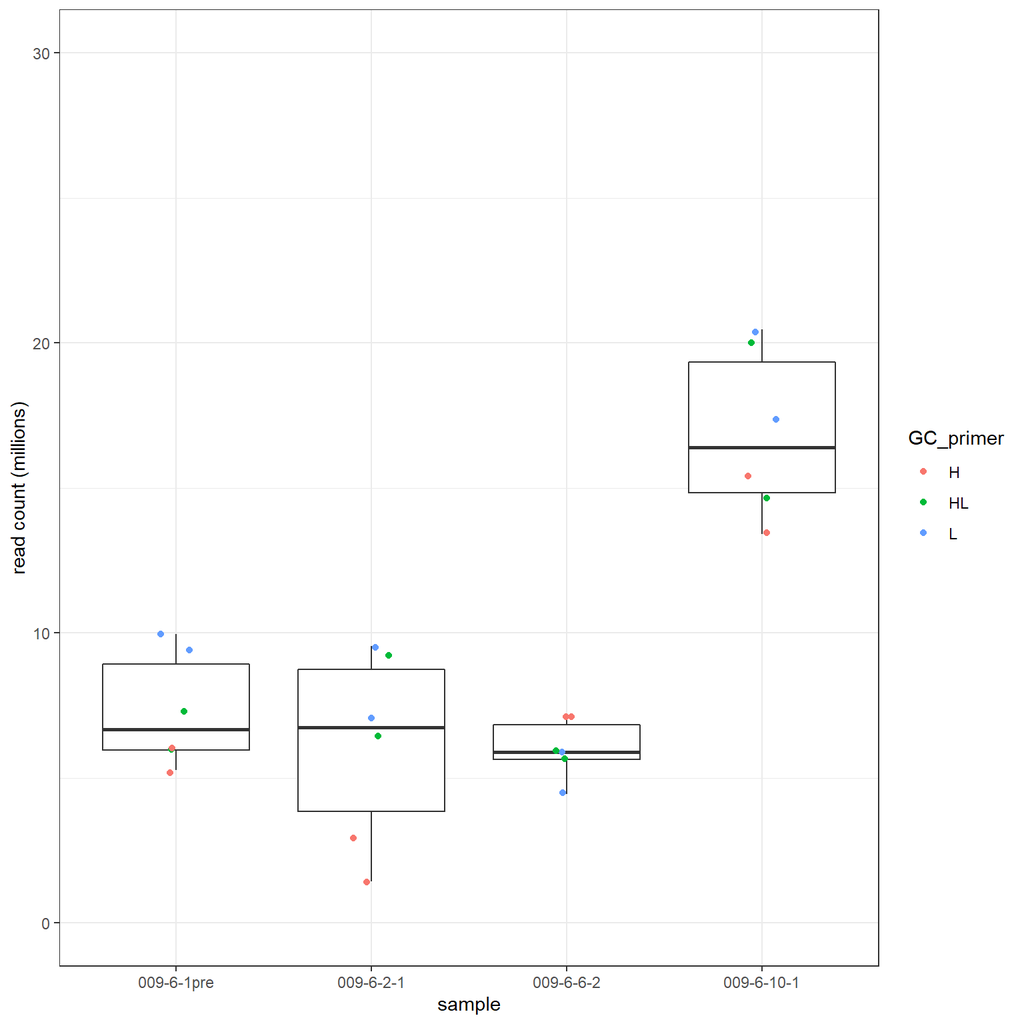

```r
data$reads <- data$read_pairs * 2

etec.data <- data[1:33,]

etec.rip.data <- subset(etec.data, GC_primer != "nrip")
etec.rip.data <- subset(etec.rip.data, GC_primer != "HLmock")

xfact  = factor(etec.rip.data$tag, levels=c("009-6-1pre", "009-6-2-1", "009-6-6-2","009-6-10-1"))

#pdf output
#pdf("Y:/RDRIP/etvedte/meta_ETEC/ETEC_rawreadcounts.pdf", width = 8, height = 8)

  p1 <- ggplot(etec.rip.data, aes(xfact, reads/1000000)) +
        labs(x="sample",y="read count (millions)") +
        ylim(0,30) +
        theme_bw()

  p1 + geom_boxplot(mapping=aes(x=xfact,y=etec.rip.data$reads/1000000), outlier.shape = NA) +
       geom_jitter(aes(colour = GC_primer), width = 0.1, height = 0.1)
```

```r
#pdf close
#dev.off()
```

### GEMS metagenome

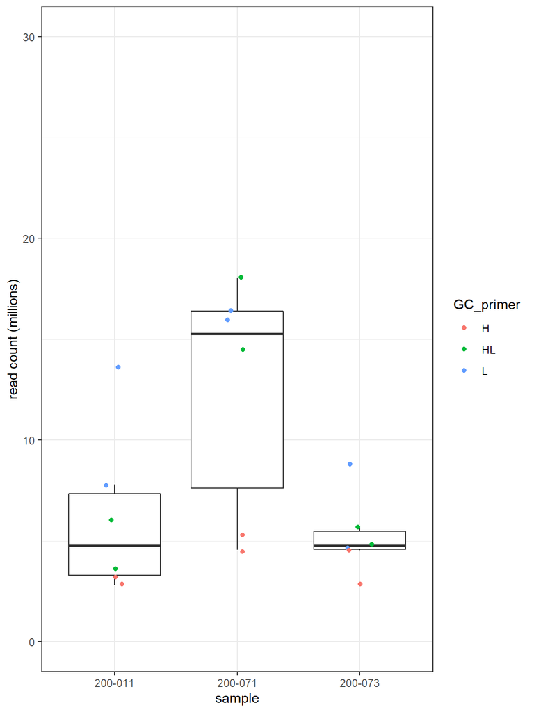

```r
gems.data <- data[34:54,]

gems.sub.data <- subset(gems.data, GC_primer != "HLmock")

xfact  = factor(gems.sub.data$tag, levels=c("200-011", "200-071", "200-073"))


#pdf output
#pdf("Y:/RDRIP/etvedte/meta_ETEC/GEMS_rawreadcounts.pdf", width = 6, height = 8)

  p1 <- ggplot(gems.sub.data, aes(xfact, reads/1000000)) +
        labs(x="sample",y="read count (millions)") +
        ylim(0,30) +
        theme_bw()

  p1 + geom_boxplot(mapping=aes(x=xfact,y=gems.sub.data$reads/1000000), outlier.shape = NA) +
       geom_jitter(aes(colour = GC_primer), width = 0.1, height = 0.1)
```

```r
#pdf close
#dev.off()
```

# kraken 2

kraken2-build –download-taxonomy –db kraken2-nt  
kraken2-build –download library nt –db kraken2-nt  
kraken2-build –build –db kraken2-nt kraken2 –threads 16 –db kraken2-nt –paired –report kraken2_report.txt R1.fastq.gz R2.fastq.gz

### kraken2 domain for ETEC metagenome

domain:awk ‘$4==“D”’ kraken2_report.txt

```r
etec.data[is.na(etec.data)] <- 0
```

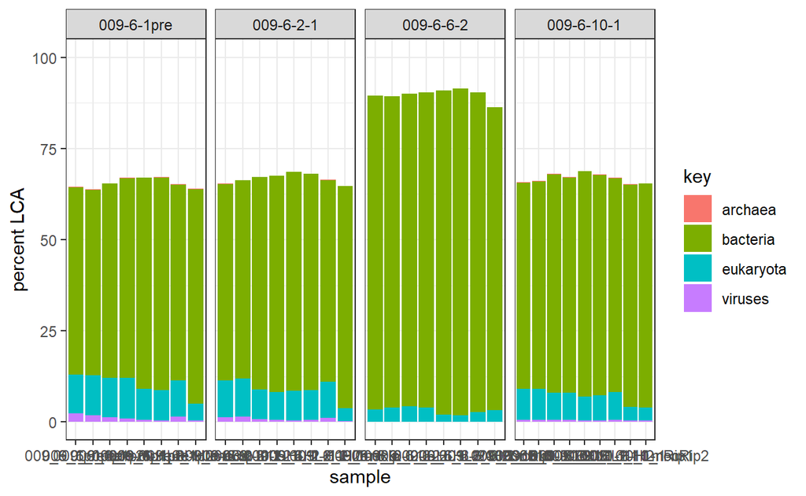

```r
etec.data$tag <- factor(etec.data$tag, levels = c("009-6-1pre", "009-6-2-1", "009-6-6-2", "009-6-10-1"))

#pdf("Y:/RDRIP/etvedte/meta_ETEC/ETEC.kraken2.domain_new.pdf", width=6.5, height=4)

etec.data %>%
  gather(key, value, c(archaea, bacteria, eukaryota, viruses)) %>%
  ggplot(aes(reorder(sample, sample_numeric), value)) +
  geom_col(aes(fill = key)) +
  facet_wrap(~ tag, ncol = 4, scales = "free_x") +
  scale_y_continuous(name = "percent LCA", limits=c(0,100)) +
  scale_x_discrete(name = "sample") +
  theme_bw()
```

```r
#pdf close
#dev.off()
```

Order is by GC primer: L1, L2, HL1, HL2, H1, H2, HLmock, non-Riptide1, nonRiptide2 (only 009-6-10-1)

### kraken2 phylum for ETEC metagenome

phylum:awk ‘$4==“P”’ kraken2_report.txt | awk ‘$1>0.5’ -

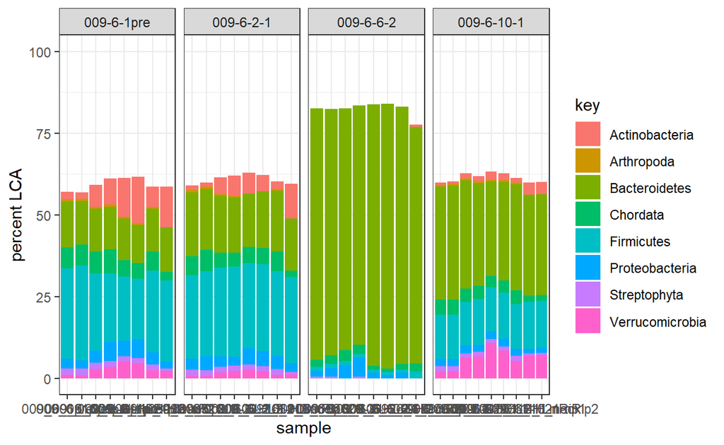

```r
#pdf("Y:/RDRIP/etvedte/meta_ETEC/ETEC.Rip.phylum_new.pdf", width=6.5, height=4)

  etec.data %>%
    gather(key, value, -c(sample, sample_numeric,barcode, experiment, tag, GC_primer, replicate, read_pairs, classified, archaea, bacteria, eukaryota, viruses, reads)) %>%
    ggplot(aes(reorder(sample, sample_numeric), value)) +
    geom_col(aes(fill = key)) +
    facet_wrap(~ tag, ncol = 4, scales = "free_x") +
    scale_y_continuous(name = "percent LCA", limits=c(0,100)) +
    scale_color_brewer(palette="Set3") +
    scale_x_discrete(name = "sample") +
    theme_bw()
```

```r
#dev.off()
```

### kraken2 domain for GEMS metagenome

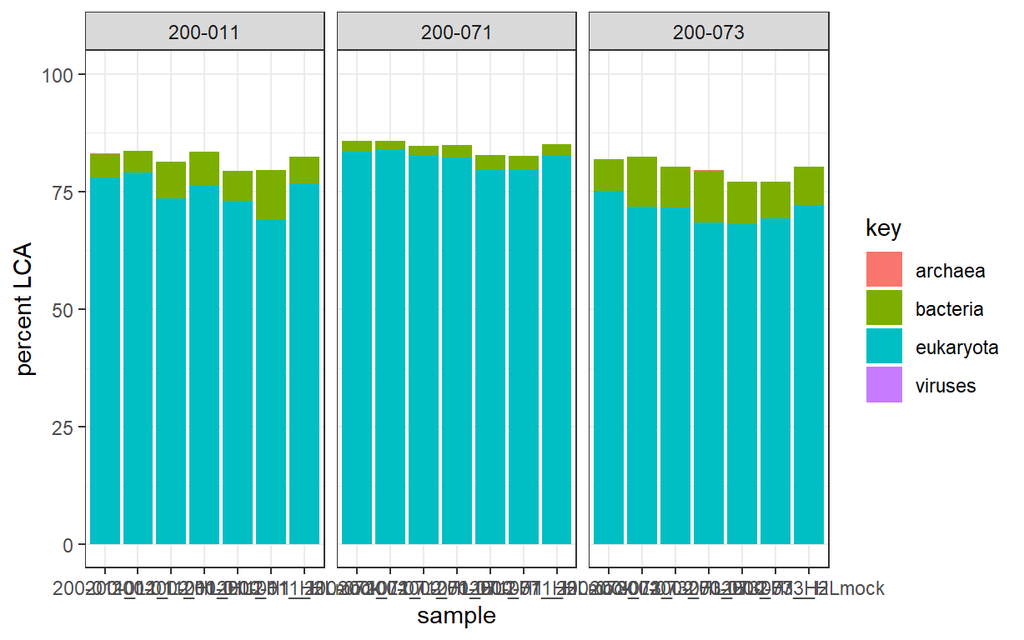

### kraken2 phylum for GEMS metagenome

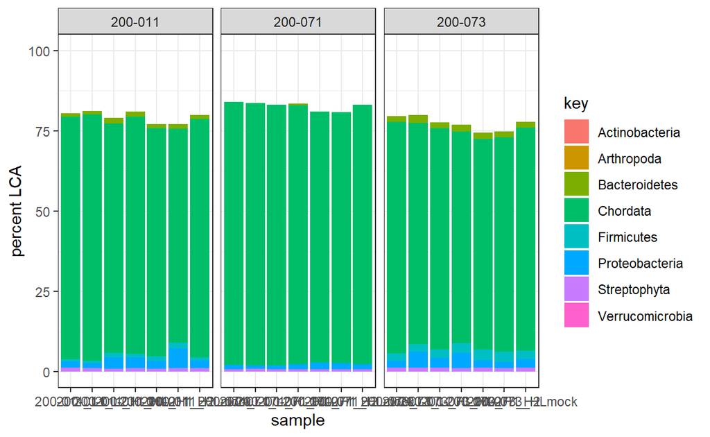

Document processed on: 2019-11-05 .